```python
from IPython.display import Image
import numpy as np
from matplotlib import pyplot as plt
%matplotlib inline
from adsy.display import extended_styles
from scipy import interpolate
extended_styles()
```

Toggle Input

# Main Findings

- Even with very simple "stochastic processes", the number of samples needed to compute expected so that the PGT distribution looks like the "true" distribution is prohibitively high.
- With the "is-best" version, the PGT distribution tends to be peaky, does not easily align with the traditional PGT distribution and the location of the peaks are not immediately predictable.
- If we don't expect the modified PGT algorithms to yield results "close to" the exact PGT distribution under the traditional algorithm, we have no benchmark in which we can compare.
- The "ranking" alternative gives the closest approximation to the traditional PGT distribution. Together with the fact that the tradtional PGT algorithm is the "ranking" algorithm with $N, M'=\infty$, I would say that is the best bet as of now.

# New PGT methods in a simultaneous Bertrand Game

The structure of the games is as follows:

- First, a random variable is realized that determines the state of the market.
  - The states are differentiated by the intercept of the Demand Curve
- Both players observe the state of the market and selects a price
- Market demand for product $i$ is given by $q_i=a_s - \gamma p_i + \theta p_j$. The intercept is indexed by s, denoting the state of the market.
- Players earn a profit given by $\pi(p_i, p_j)=p_i q_i - cq_i$.
- To begin $p_i=4, p_j=2$ and the possible values of $a$ are $\{94,194,294\}$
- The players can choose quantities in $\{25, 35,50,65,75\}$
  - $25, 50,75$ are the Nash equilibrium for markte states $94,194,294$ respectively.
- $c=2$
- Players have $5^3=125$ profiles for a total of 15625 joint profiles.
- Let's first look at the traditional PGT distribution.

### Code for Traditional PGT

```python
exactpgt = np.copy(a)
```

```python
import itertools
```

```python
p1_strat_space = list(itertools.product([25,35, 50,65,75],[25,35,50,65,75],[25,35,50,65,75]))
p2_strat_space = list(itertools.product([25,35, 50,65,75],[25,35,50,65,75],[25,35,50,65,75]))
market_intercepts = [94, 194, 294]
gamma = 3
theta = 2
```

```python
def get_quantity(intercept, own_price, other_price, gamma=3, theta=2):
    return max(0, intercept - gamma*own_price + theta*other_price)
```

```python
def get_EU(p1strat, p2strat, gamma=3, theta=2, intercepts=market_intercepts, c=2):
    """
    Return's both player's EU for a given strat profile
    """
    p1eu =sum([1./len(intercepts) * (p1strat[i]-c)*get_quantity(intercepts[i], p1strat[i], p2strat[i],
                                                  gamma, theta) for i in range(len(intercepts))])
    p2eu =sum([1./len(intercepts) * (p2strat[i]-c)*get_quantity(intercepts[i], p2strat[i], p1strat[i],
                                                  gamma, theta) for i in range(len(intercepts))])
    return p1eu, p2eu
```

```python
def get_intel(p1_strat_space, p2_strat_space, f=None):
    """
    F is the quantity whose distribution we are interested in.  If none,
    the function returns (eu1. eu2, intel)
    """
    eus = []
    intels = []
    for p1strat in p1_strat_space:
        for p2strat in p2_strat_space:
            p1intel=0
            p2intel=0
            profeu =get_EU(p1strat, p2strat)
            eus.append(profeu)
            for p1_alt in p1_strat_space:
                if get_EU(p1_alt, p2strat)[0] <= profeu[0]:
                    p1intel += 1
            for p2_alt in p2_strat_space:
                if get_EU(p1strat, p2_alt)[1] <= profeu[1]:
                    p2intel += 1
            intel=p1intel*p2intel/float(len(p1_strat_space)**2)
            intels.append(intel)
            #if intel==1:
            #    print p1strat, p2strat, "\n"

    return eus, intels
```

```python
def plot_cdf(quantity, intels, exponent=1):
    intels= np.asarray(intels)
    quantity = np.asarray(quantity)
    intels=intels**exponent
    normedprobs = intels/sum(intels)
    d={}
    # DefaultDict is not working right now.  I will just do
    # this the poor man's way
    for util_ix in range(len(quantity)):
        d[quantity[util_ix]] = 0
    for util_ix in range(len(quantity)):
        d[quantity[util_ix]] += normedprobs[util_ix]
    u2 = []
    p2 = []
    for (key, val) in d.iteritems():
        u2.append(key)
        p2.append(val)
    std_util = sorted(u2)
    std_util_ix = np.argsort(u2)
    std_prob = [p2[ix] for ix in std_util_ix]
    return std_util, np.cumsum(std_prob)
```

```python
a=get_intel(p1_strat_space, p2_strat_space)
```

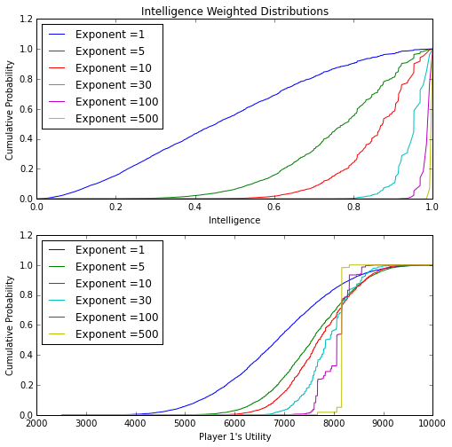

```python
fig, (ax1, ax2) =plt.subplots(2, figsize=(8,8))
p1utils = [x[0] for x in a[0]]
for j in [1,5,10,30,100,500]:
    x,y = plot_cdf(a[1],a[1], exponent=j)
    ax1.plot(x,y, label="Exponent =" +str(j))
    x,y = plot_cdf(p1utils, a[1], exponent=j)
    ax2.plot(x,y, label="Exponent =" +str(j))
ax1.legend(loc=2)
ax1.set_title("Intelligence Weighted Distributions")
ax1.set_ylabel("Cumulative Probability")
ax1.set_xlabel("Intelligence")
ax2.legend(loc=2)
#ax2.set_title("Intelligence Weighted Distributions")
ax2.set_ylabel("Cumulative Probability")
ax2.set_xlabel("Player 1\'s Utility")
```

# Monte Carlo Based PGT

Let's now do PGT but instead of doing it exhaustively, "pretend" that we need to do Monte Carlo.

```python
#PGT parameters
n_joint_profiles = 3000
n_alternative_profiles = 25
```

```python
def Traditional_PGT(p1_strat_space, p2_strat_space, n_joint, n_alt):
    eus = []
    intels = []
    sampled = []
    sizespace = len(p1_strat_space)
    i=0
    while i<n_joint:
        p1intel=0
        p2intel=0
        p1strat = p1_strat_space[np.random.random_integers(0, sizespace-1,1)[0]]
        p2strat = p2_strat_space[np.random.random_integers(0, sizespace-1,1)[0]]
        if [p1strat, p2strat] not in sampled:
            i += 1
            sampled.append([p1strat, p2strat])
            profeu =get_EU(p1strat, p2strat)
            eus.append(profeu)
            p1altctr = 0
            p1altsamped = []
            while p1altctr <(n_alt):
                p1_alt = p1_strat_space[np.random.random_integers(0, sizespace-1,1)[0]]
                if p1_alt not in p1altsamped:
                    p1altsamped.append(p1_alt)
                    p1altctr+=1
                    if get_EU(p1_alt, p2strat)[0] <= profeu[0]:
                        p1intel += 1
            p2altctr = 0
            p2altsamped = []
            while p2altctr<n_alt:
                p2_alt = p2_strat_space[np.random.random_integers(0, sizespace-1,1)[0]]
                if p2_alt not in p2altsamped:
                    p2altctr +=1
                    p2altsamped.append(p2_alt)
                    if get_EU(p1strat, p2_alt)[1] <= profeu[1]:
                        p2intel += 1
            intel=p1intel*p2intel/float(n_alt**2)
            intels.append(intel)
            #if intel==1:
            #    print p1strat, p2strat, "\n"
    return eus, intels
```

```python
def make_cdf(pgt_result_1):
    fig, (ax1, ax2) =plt.subplots(2, figsize=(12,12))
    p1utils = [x[0] for x in pgt_result_1[0]]
    c={10:'r', 100:'b', 500:'g'}
    for j in [10,100,500]:
        p1utils = [x[0] for x in pgt_result_1[0]]
        x,y = plot_cdf(pgt_result_1[1],pgt_result_1[1], exponent=j)
        cs = np.random.random(3)
        ax1.plot(x,y, label="MC-PGT Exponent =" +str(j), color=c[j])
        x1,y1 = plot_cdf(a[1],a[1], exponent=j)
        ax1.plot(x1,y1, '--', label="Exact Exponent =" +str(j),color=c[j])
        x,y = plot_cdf(p1utils, pgt_result_1[1], exponent=j)
        ax2.plot(x,y, label="MC-PGT Exponent =" +str(j),color=c[j])
        x1,y1 = plot_cdf([x[0] for x in a[0]], a[1], exponent=j)
        ax2.plot(x1,y1, '--',label="Exact Exponent =" +str(j),color=c[j])
    ax1.legend(loc=2, ncol=1)
    ax1.set_title("Intelligence Weighted Distributions")
    ax1.set_ylabel("Cumulative Probability")
    ax1.set_xlabel("Intelligence")
    ax2.legend(loc=2, ncol=1)
    #ax2.set_title("Intelligence Weighted Distributions")
    ax2.set_ylabel("Cumulative Probability")
    ax2.set_xlabel("Player 1\'s Utility")
    #ax2.set_xlim(6000,9500)
    return None
```

```python
pgt_result_1 = Traditional_PGT(p1_strat_space, p2_strat_space, 1000, 30)
```

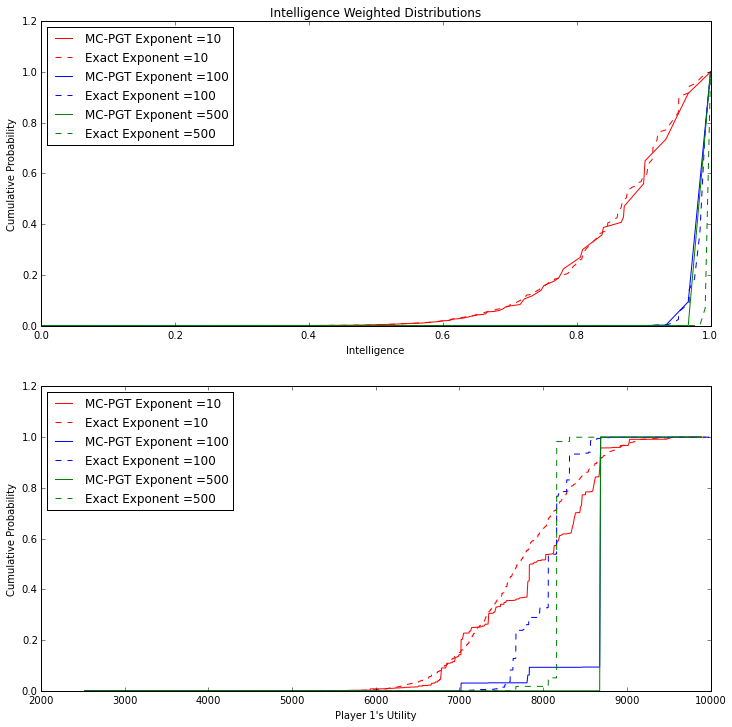

```python
make_cdf(pgt_result_1)
```

**Comment** Even if the distribution of intelligences of a Monte Carlo approach closely approximate the true distribution of intelligences, it does not mean that the distribution of a "quantity of interest" closely approximates the quantity of interest.

#### Some Counting, Part I

In the above example, 1000 (out of the possible 15000+) joint profiles were sampled. For each joint profile, 30 (out of 125) alternative profiles were sampled. That means, the total number of expected utility calculations (assuming that no profile gets sampled twice) would be $1000\times(30+30)=60000$.

Note that in practice, this is way beyond the number of expected utilities we would have to compute (there are only 15K joint profiles in the game). In our simple event-driven Bertrand game, we might gain a lot by "remembering" expected utilities. However, in a game like the one Youngjun is working on where each player's strategy space is $7^{8\times 10^6}$, we probably won't be ever resample the same profile.

Let's see what happens when we raise the number of alternative profiles:

```python
pgt_result_2 = Traditional_PGT(p1_strat_space, p2_strat_space, 1000, 60)
```

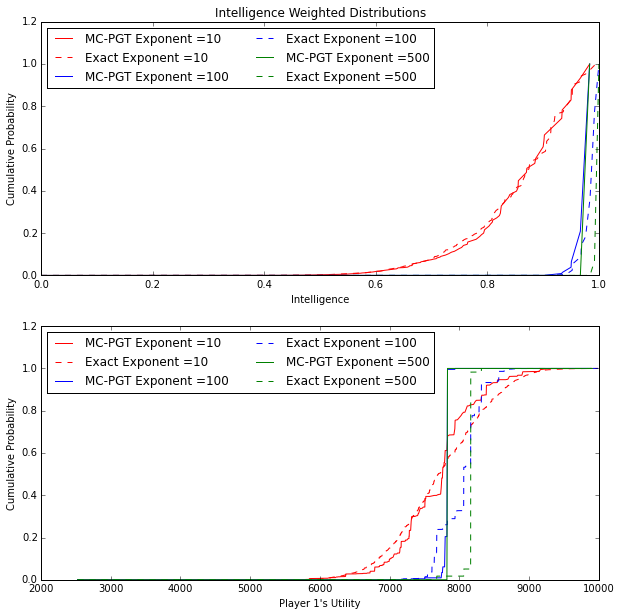

```python
make_cdf(pgt_result_2)
```

We still see a decent amount of separation between the exact distribution and the Monte Carlo-based PGT distribution. Let's see what happens when we raise the number of samples tp 7000, approximately half of the joint strategy profile space.

```python
pgt_result_3 = Traditional_PGT(p1_strat_space, p2_strat_space, 7000, 30)
```

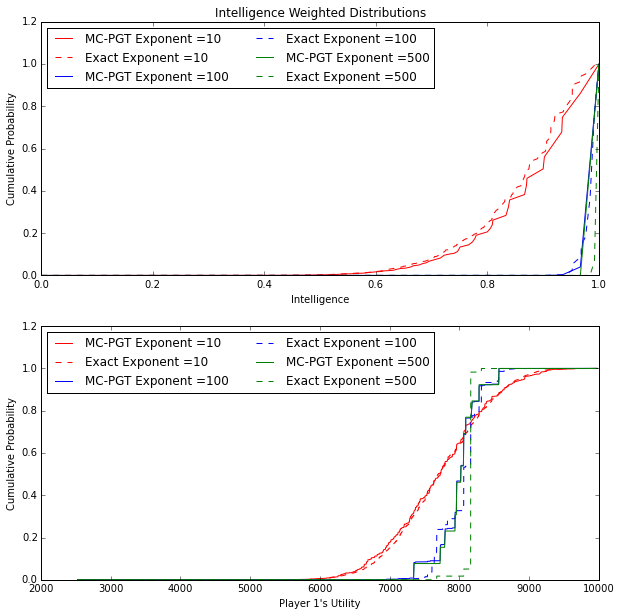

```python
make_cdf(pgt_result_3)
```

Now the expected utility distributions are much closer together.

### Estimating expected utility

Now, we will assume that we cannot calculate expected utility exactly but instead need to estimate it by sampling the "stochastic process". Let's let the number of samples we take be $30$ in this intial experiment.

```python
def get_EU_estimate(N, p1strat, p2strat, gamma=3, theta=2, intercepts=market_intercepts, c=2):
    """
    Return's both player's EU for a given strat profile
    """
    p1eu = 0
    p2eu = 0
    n=0
    while n < N:
        n += 1
        i = np.random.random_integers(0,2,1)
        p1eu += (p1strat[i]-c)*get_quantity(intercepts[i], p1strat[i], p2strat[i], gamma, theta)
        p2eu += (p2strat[i]-c)*get_quantity(intercepts[i], p2strat[i], p1strat[i], gamma, theta)
    return p1eu/float(N), p2eu/float(N)
```

```python
def Traditional_PGT_sampling(p1_strat_space, p2_strat_space, n_joint, n_alt, N):
    eus = []
    intels = []
    sampled = []
    sizespace = len(p1_strat_space)
    i=0
    while i<n_joint:
        p1intel=0
        p2intel=0
        p1strat = p1_strat_space[np.random.random_integers(0, sizespace-1,1)[0]]
        p2strat = p2_strat_space[np.random.random_integers(0, sizespace-1,1)[0]]
        if [p1strat, p2strat] not in sampled:
            i += 1
            sampled.append([p1strat, p2strat])
            profeu =get_EU_estimate(N, p1strat, p2strat)
            eus.append(profeu)
            p1altctr = 0
            p1altsamped = []
            while p1altctr <(n_alt):
                p1_alt = p1_strat_space[np.random.random_integers(0, sizespace-1,1)[0]]
                if p1_alt not in p1altsamped:
                    p1altsamped.append(p1_alt)
                    p1altctr+=1
                    if get_EU_estimate(N,p1_alt, p2strat)[0] <= profeu[0]:
                        p1intel += 1
            p2altctr = 0
            p2altsamped = []
            while p2altctr<n_alt:
                p2_alt = p2_strat_space[np.random.random_integers(0, sizespace-1,1)[0]]
                if p2_alt not in p2altsamped:
                    p2altctr +=1
                    p2altsamped.append(p2_alt)
                    if get_EU_estimate(N, p1strat, p2_alt)[1] <= profeu[1]:
                        p2intel += 1
            intel=p1intel*p2intel/float(n_alt**2)
            intels.append(intel)
            #if intel==1:
            #    print p1strat, p2strat, "\n"
    return eus, intels
```

```python
pgt_result_4 = Traditional_PGT_sampling(p1_strat_space, p2_strat_space, 1000, 30,30)
```

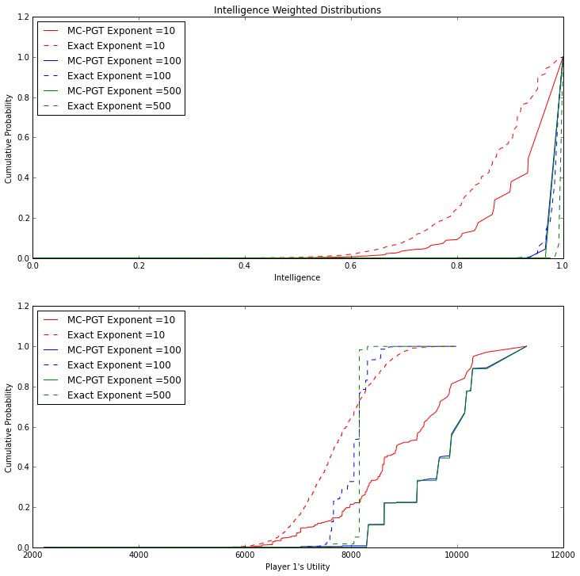

```python
make_cdf(pgt_result_4)
```

**Comment** With a very simple stochastic process, using a finite number of samples to estimate expected utility can cause the PGT distribution to be relatively "far away" from its "true" distribution.

For the heck of it, let's check the convergence properties and raise the number of samples to 120

```python
pgt_result_5 = Traditional_PGT_sampling(p1_strat_space, p2_strat_space, 1000, 30,120)
```

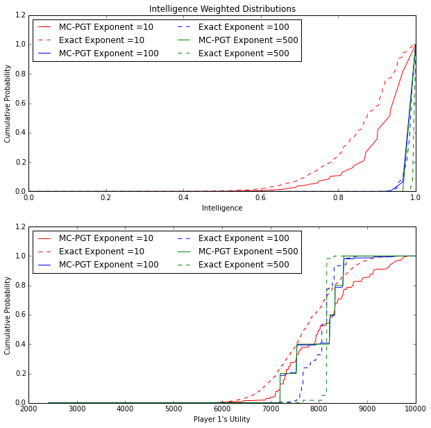

```python
make_cdf(pgt_result_5)
```

Increasing the number of samples does bring the distributions a bit closer together but we are at 120 samples for a *very simple* stochastic process.

#### Some Counting, Part II

In the previous example, we sampled 1000 profiles and compared it to 30 alternative profiles. To estimate the expected utility, we simulated the game 120 times. This leads to $1000 \times (30+30)\times120=7,200,000$ simulations of the stochastic process.

**Comment** Since a very simple stochastic process requires a large number of samples to compute expected utility (and without such, the monte carlo distribution can be significantly different from the "theoretical distribution"), it will be necessary to redefine the intelligence measure.

# PGT Modification 1

Here, we use the first modification of PGT where the probability of player 1's strategy against player 2's strategy is the number of times that the strategy is the best against player 2's strategy.

```python
def PGT_mod_1(p1_strat_space, p2_strat_space, n_joint, n_alt, N,M):
    eus = []
    intels = []
    sampled = []
    sizespace = len(p1_strat_space)
    i=0
    while i<n_joint:
        p1intel=0
        p2intel=0
        p1strat = p1_strat_space[np.random.random_integers(0, sizespace-1,1)[0]]
        p2strat = p2_strat_space[np.random.random_integers(0, sizespace-1,1)[0]]
        if [p1strat, p2strat] not in sampled:
            i += 1
            sampled.append([p1strat, p2strat])
            profeu =get_EU_estimate(N, p1strat, p2strat)
            eus.append(profeu)
            m =0
            while m<M:
                p1altctr = 0
                p1altsamped = []
                m +=1
                while p1altctr <(n_alt):
                    p1_alt = p1_strat_space[np.random.random_integers(0, sizespace-1,1)[0]]
                    if p1_alt not in p1altsamped:
                        p1altsamped.append(p1_alt)
                        p1altctr+=1
                        if get_EU_estimate(N,p1_alt, p2strat)[0] > profeu[0]:
                            p1altctr = n_alt + 1
                    if p1altctr == n_alt:
                        p1intel += 1
            m=0
            while m < M:
                p2altctr = 0
                p2altsamped = []
                m +=1
                while p2altctr<n_alt:
                    p2_alt = p2_strat_space[np.random.random_integers(0, sizespace-1,1)[0]]
                    if p2_alt not in p2altsamped:
                        p2altctr +=1
                        p2altsamped.append(p2_alt)
                        if get_EU_estimate(N, p1strat, p2_alt)[1] > profeu[1]:
                            p2altctr = n_alt + 1
                    if p2altctr == n_alt:
                        p2intel += 1
            intel=p1intel*p2intel/float(M**2)
            intels.append(intel)
            #if intel==1:
            #    print p1strat, p2strat, "\n"
    return eus, intels, sampled
```

#### Some Counting, Part III

For the initial experiment, we will sample 1000 joint profiles. For each profile, the expected utility will be computed using 30 samples. The numer of alternative strategy profiles to compare against are 30 and the number of times to sample a set of alternative profiles is 30. That means, the number of simulations of the game are **at most** $1000*(30*30*(30+30)) = 54,000,000$

**Comment** One benefit of the "is best" method is that when sampling alternative profiles, as soon as we find an alternative profile that earns a higher expected utility than the "outer" profile, we can break the inner loop.

```python
pgt_result_6 = PGT_mod_1(p1_strat_space, p2_strat_space, 1000, 30,30,30)
```

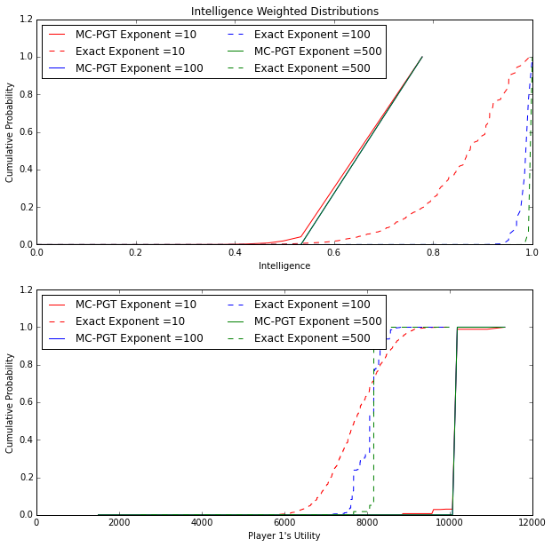

```python
make_cdf(pgt_result_6)
```

The PGT distributions seem to be much more concentrated. Let's see what happens when we lower the number of profiles we compare the outer profile to.

```python
pgt_result_7 = PGT_mod_1(p1_strat_space, p2_strat_space, 1000, 5,30,30)
```

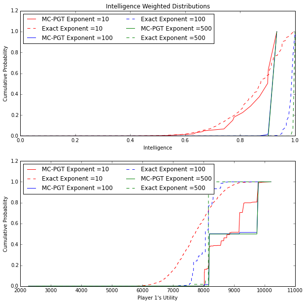

```python
make_cdf(pgt_result_7)
```

As expected, the distribution is *slightly* less concentrated, but not much. In hindsight, this is not a surprising result. Let's see what happens when we raise $N$, the number of samples to compute expected utility.

```python
pgt_result_8 = PGT_mod_1(p1_strat_space, p2_strat_space, 1000, 5,100,30)
```

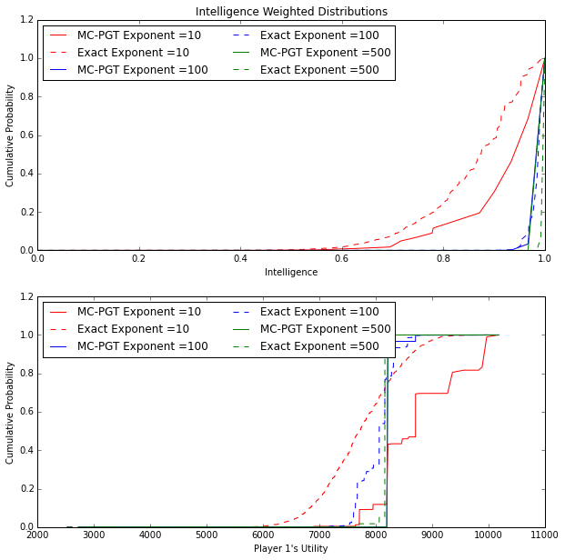

```python
make_cdf(pgt_result_8)
```

The distribution actually gets better for higher exponents! The reason is that when the number of samples to estimate expected utility is high, the "best responses" wind up receiving the most weight. In other words, when $N$ goes to infinity, only Nash equilibria get a positive weight.

Let's see what happens when we raise the number of alternative profiles sampled.

```python
pgt_result_9 = PGT_mod_1(p1_strat_space, p2_strat_space, 1000, 30,100,30)
```

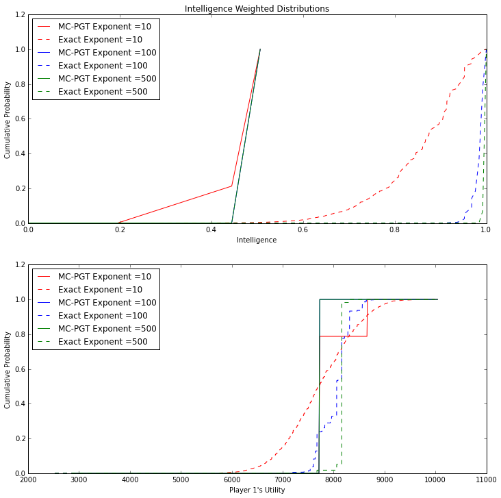

```python
make_cdf(pgt_result_9)
```

This time, the distribution is waaaay off. The reason is that relatively "good" strategies can receive little weight if there are other strategies that yield "similar" expected utility. For example, suppose that against a certain strategy of player 2, player 1 has 20 strategies that give player 1 close to the same expected utility. However, because of the variance, the "best" of those strategies is going to receive relatively little weight. Let's repeat that experiment one more time with the same parameters.

```python
pgt_result_10 = PGT_mod_1(p1_strat_space, p2_strat_space, 1000, 30,100,30)
```

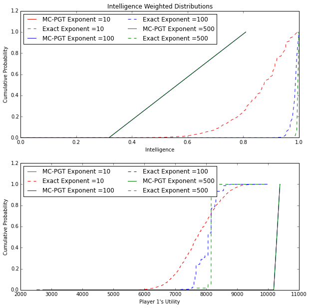

```python
make_cdf(pgt_result_10)
```

A reason for the peakedness is that in general, the un-raised inteligences are smaller. Therefore, when we raise them to large exponents, the largest intelligence gets even more relative weight. I am at a loss as to why the weight is put where it is. I speculate that the strategy profile $[(50, 65, 65), (50, 75, 75)]$ only has a small number of alternative profiles that do better for each player but those profiles do much better.

**Comment** With the "proportion of times the best" method. The disttibution becomes very peaked very quickly but the variance in where it peaks is large.

```python
pgt_result_11 = PGT_mod_1(p1_strat_space, p2_strat_space, 1000, 30,2,50)
```

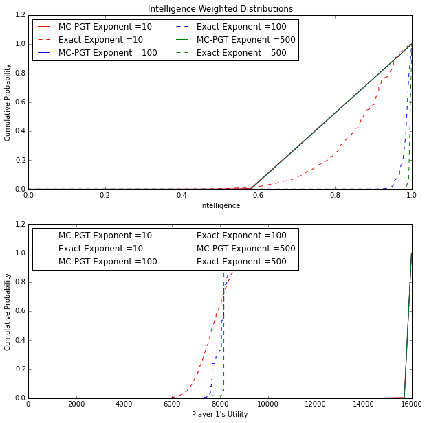

```python
make_cdf(pgt_result_11)
```

I did *not* use the same seed for the one run case. Therefore, the profiles with the highest intelligence are the one when the random seed realizes a high market state for both players and both players play 75 in a high market state.

```python
pgt_result_11 = PGT_mod_1(p1_strat_space, p2_strat_space, 1000, 5,30,50)
```

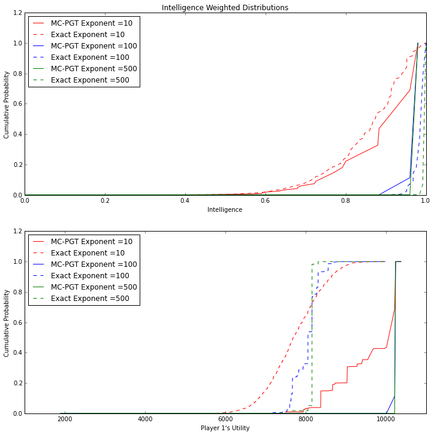

```python
make_cdf(pgt_result_11)
```

# Ranking PGT Modification

```python
def PGT_mod_2(p1_strat_space, p2_strat_space, n_joint, n_alt, N,M):
    eus = []
    intels = []
    sampled = []
    sizespace = len(p1_strat_space)
    i=0
    while i<n_joint:
        p1intel=0
        p2intel=0
        p1strat = p1_strat_space[np.random.random_integers(0, sizespace-1,1)[0]]
        p2strat = p2_strat_space[np.random.random_integers(0, sizespace-1,1)[0]]
        if [p1strat, p2strat] not in sampled:
            i += 1
            sampled.append([p1strat, p2strat])
            profeu =get_EU_estimate(N, p1strat, p2strat)
            eus.append(profeu)
            m =0
            while m<M:
                p1altctr = 0
                p1altsamped = []
                m +=1
                p1alt_utils = []
                while p1altctr <(n_alt):
                    p1_alt = p1_strat_space[np.random.random_integers(0, sizespace-1,1)[0]]
                    if p1_alt not in p1altsamped:
                        p1altsamped.append(p1_alt)
                        p1altctr+=1
                        p1alt_utils.append(get_EU_estimate(N,p1_alt, p2strat)[0])
                p1intel += np.searchsorted(np.sort(p1alt_utils),profeu[0])

            m=0
            while m < M:
                p2altctr = 0
                p2altsamped = []
                m +=1
                p2alt_utils=[]
                while p2altctr<n_alt:
                    p2_alt = p2_strat_space[np.random.random_integers(0, sizespace-1,1)[0]]
                    if p2_alt not in p2altsamped:
                        p2altctr +=1
                        p2altsamped.append(p2_alt)
                        p2alt_utils.append(get_EU_estimate(N,p1_alt, p2strat)[0])
                p2intel += np.searchsorted(np.sort(p2alt_utils),profeu[1])
            intel=p1intel*p2intel/float((n_alt*M)**2)
            intels.append(intel)
            #if intel==1:
            #    print p1strat, p2strat, "\n"
    return eus, intels, sampled
```

```python
pgt_result_12 = PGT_mod_2(p1_strat_space, p2_strat_space, 1000, 30,30,50)
```

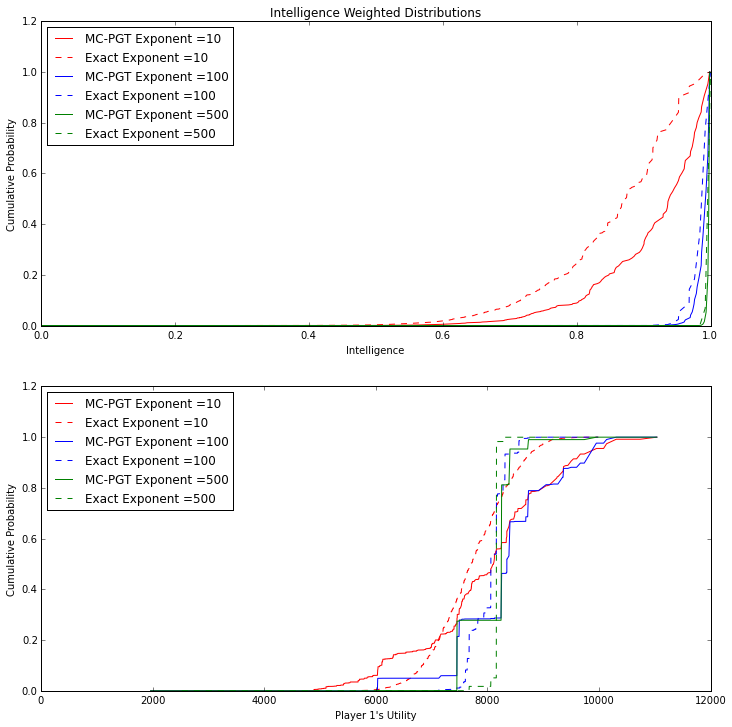

```python
make_cdf(pgt_result_12)
```

For another experiement, let's see what happens when we raise the total number of joint profiles. keeping all other parameters constant.

```python
pgt_result_13 = PGT_mod_2(p1_strat_space, p2_strat_space, 3000, 30,30,50)
```

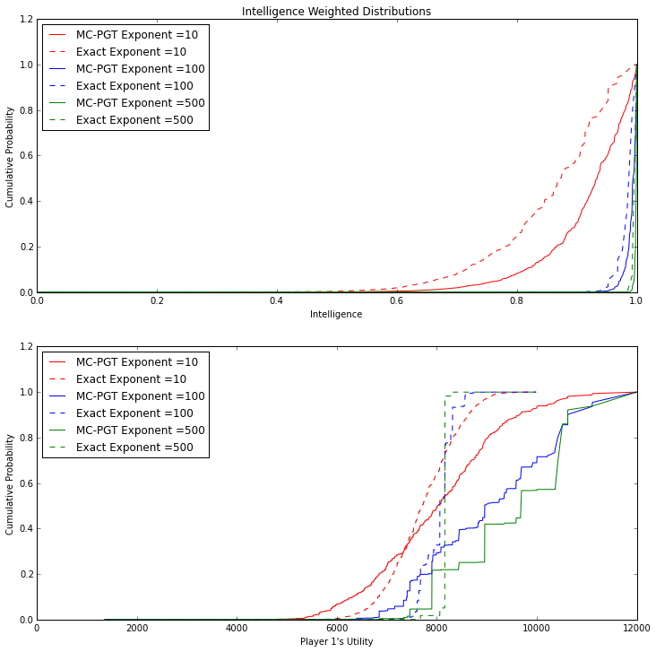

```python
make_cdf(pgt_result_13)
```

Interestingly, the fit is *worse*.

#### Some Counting Part IV

If we let $N$ be the number of sample sused to computed expected utility and $M'$ the number of alternative strategy profiles sampled, then the total number of samples of the stochastic process required to get the intelligence of 1 joint profile under the traditional PGT algorithm is $2*M'\times N$. Under the "ranking" method, if we let $M$ be the number of times we compute the rank for the "outer loop" joint profile, then the number of samples we need is $2\times M \times M' \times N$. That is a factor of $M$ greater than in the traditional PGT. What we need to see is if those $M$ extra samples can instead be included in the calculation of intelligence under the tradtional algorithm. In other words, we can simply use $N\times M$ samples to estimate expected utility in the traditional way. Let's do this...

```python
pgt_result_14 = Traditional_PGT_sampling(p1_strat_space, p2_strat_space, 3000, 30,1500)
```

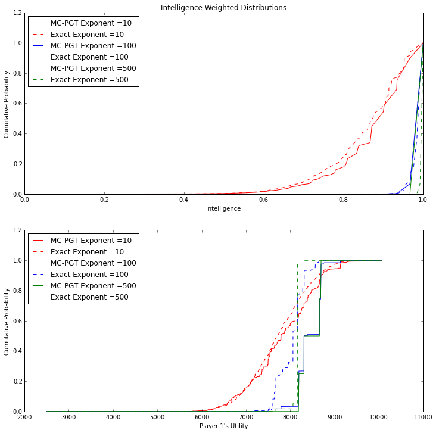

```python
make_cdf(pgt_result_14)
```

The results suggest that the traditional PGT algorithm performs the best.

# A Deeper Look at Convergence

Let's first look the original PGT version. To do this we will look at the 90% confidence bands for the CDF

```python
convergence_results_1 = []
for _ in xrange(100):
    convergence_results_1.append(Traditional_PGT_sampling(p1_strat_space, p2_strat_space, 1000, 30,30))
```

```python
from scipy import interpolate
def make_interp_func(quantity, intels, exponent=1):
    intels= np.asarray(intels)
    intels=np.insert(intels, 0, 0)
    intels=np.insert(intels, len(intels), 0)
    quantity = np.asarray(quantity)
    quantity=np.insert(quantity, 0,0)
    quantity=np.insert(quantity, len(quantity),13001)
    intels=intels**exponent
    normedprobs = intels/sum(intels)
    d={}
    # DefaultDict is not working right now.  I will just do
    # this the poor man's way
    for util_ix in range(len(quantity)):
        d[quantity[util_ix]] = 0
    for util_ix in range(len(quantity)):
        d[quantity[util_ix]] += normedprobs[util_ix]
    u2 = []
    p2 = []
    for (key, val) in d.iteritems():
        u2.append(key)
        p2.append(val)
    std_util = sorted(u2)
    std_util_ix = np.argsort(u2)
    std_prob = [p2[ix] for ix in std_util_ix]
    cdf_vals = np.cumsum(std_prob)
    f = interpolate.interp1d(std_util, cdf_vals)
    return f

def plot_ci_cdf(resultlist, player=0, pgtexact=True):
    exponents = [1,5,30]
    fig, axs = plt.subplots(3, figsize=(10,10))
    fig.suptitle("CDF of Player 1\'s Expected Utility", size=20)
    for ix in [0,1,2]:
        interpfuncts = []
        for r in resultlist:
            p1util = [x[player] for x in r[0]]
            intels = r[1]
            interpfuncts.append(make_interp_func(p1util, intels, exponents[ix]))
        utilrange = np.arange(2000, 12000, 10)
        cdfvals= []
        for f in interpfuncts:
            cdfvals.append(f(utilrange))
        cdfvals = np.asarray(cdfvals)
        lower95 = []
        upper95 = []
        for col_ix in range(cdfvals.shape[1]):
            col = cdfvals[:,col_ix]
            colstd = np.sort(col)
            lower95.append(colstd[4])
            upper95.append(colstd[-5])
        ax1 = axs[ix]
        ax1.plot(utilrange, lower95, '--', label = "Lower 5%")
        ax1.plot(utilrange, upper95, '--', label= "Upper 5%")
        if pgtexact:
            x1,y1 = plot_cdf([x[0] for x in exactpgt[0]], exactpgt[1], exponent=exponents[ix])
            ax1.plot(x1,y1,color="black", label="True Distribution")
        ax1.legend(loc=2)
        ax1.set_title("Exponent =" +str(exponents[ix]))
    return fig,ax
```

### Experiment 1

- Algorithm: Traditional PGT Intelligence
- Expected Utility : Monte Carlo
- Number of Profiles : 1000
- Number of Alternative Profiles : 30
- Number of Samples to Estimate EU : 30

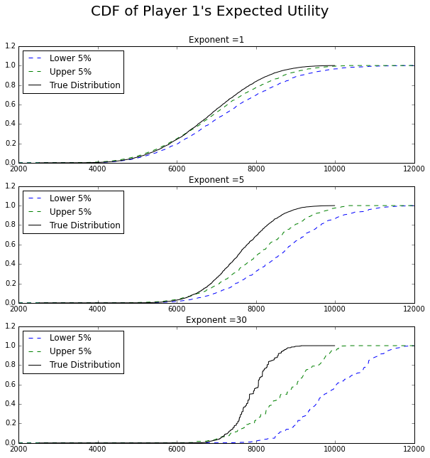

```python
plot_ci_cdf(convergence_results_1,1);
```

**Comment** When the exponent is only moderately high, the monte carlo PGT 90% confidence interval does not contain the true distribution for any value of expected utility! Let's see if this is a result of a bias in the computation of expected utility

### Experiment 2

- Algorithm: Traditional PGT Intelligence
- Expected Utility : Exact
- Number of Profiles : 1000
- Number of Alternative Profiles : 30
- Number of Samples to Estimate EU : N/A

```python
convergence_results_2 = []
for _ in xrange(100):
    convergence_results_2.append(Traditional_PGT(p1_strat_space, p2_strat_space, 1000, 30))
```

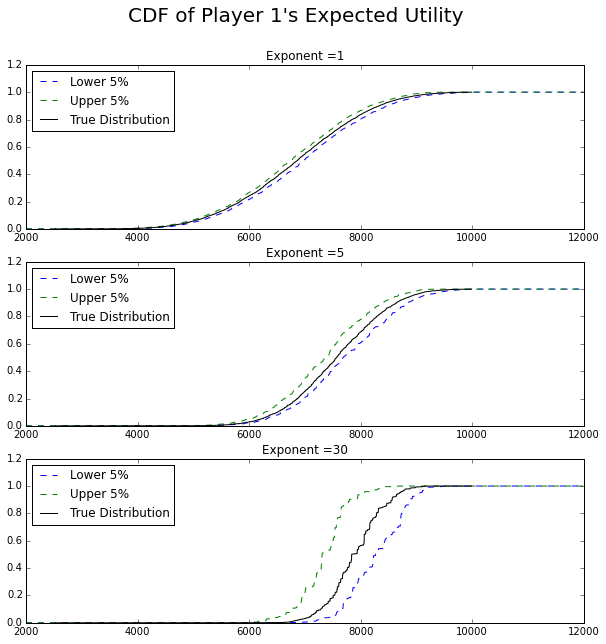

```python
plot_ci_cdf(convergence_results_2);
```

**Comment** This suggests that the varaince in the MC calculation is what is causing the CDFs to differ. Let's go back to a Monte Carlo based PGT but raise the number of samples used to compute expected utility.

### Experiment 3

- Algorithm: Traditional PGT Intelligence
- Expected Utility : Monte Carlo
- Number of Profiles : 1000
- Number of Alternative Profiles : 30
- Number of Samples to Estimate EU : 120

```python
convergence_results_3 = []
for _ in xrange(100):
    convergence_results_3.append(Traditional_PGT_sampling(p1_strat_space, p2_strat_space, 1000, 30,120))
```

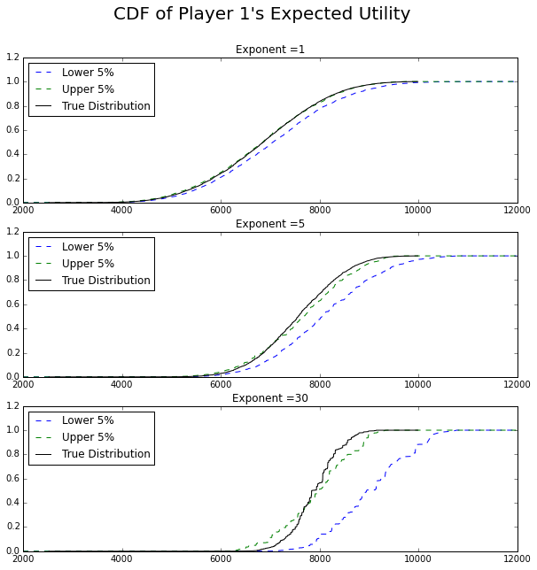

```python
plot_ci_cdf(convergence_results_3);
```

**Comment**: With more samples to estiamte expected utility, the confidence interval gets closer

### Experiment 4

- Algorithm: "Best of" PGT Intelligence
- Expected Utility : Monte Carlo
- Number of Profiles : 1000
- Number of Alternative Profiles : 30
- Number of Samples to Estimate EU : 30
- Outerloop Samples to $P(best)$ : 30

```python
convergence_results_4 = []
for _ in xrange(100):
    convergence_results_4.append(PGT_mod_1(p1_strat_space, p2_strat_space, 1000, 30,30,30))
```

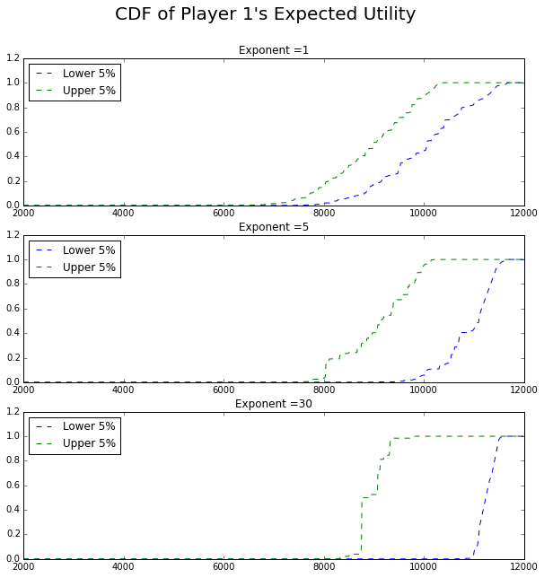

```python
plot_ci_cdf(convergence_results_4, pgtexact=False);
```

**Comment:** Huge variance here even for a moderately large number of total profile evaluations.

### Experiment 5

- Algorithm: "Best of" PGT Intelligence
- Expected Utility : Monte Carlo
- Number of Profiles : 1000
- Number of Alternative Profiles : 3
- Number of Samples to Estimate EU : 30
- Outerloop Samples to $P(best)$ : 30

```python
convergence_results_4point5 = []
for _ in xrange(100):
    convergence_results_4point5.append(PGT_mod_1(p1_strat_space, p2_strat_space, 1000, 3,30,30))
```

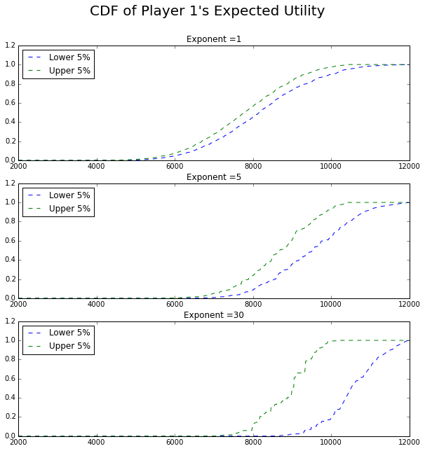

```python
plot_ci_cdf(convergence_results_4point5, pgtexact=False);
```

### Experiment 6

- Algorithm: "Ranking" PGT Intelligence
- Expected Utility : Monte Carlo
- Number of Profiles : 1000
- Number of Alternative Profiles : 30
- Number of Samples to Estimate EU : 30
- Outerloop Samples to Estimate Ranke : 30

```python
convergence_results_5 = []
for _ in xrange(100):
    convergence_results_5.append(PGT_mod_2(p1_strat_space, p2_strat_space, 1000, 30,30,30))
```

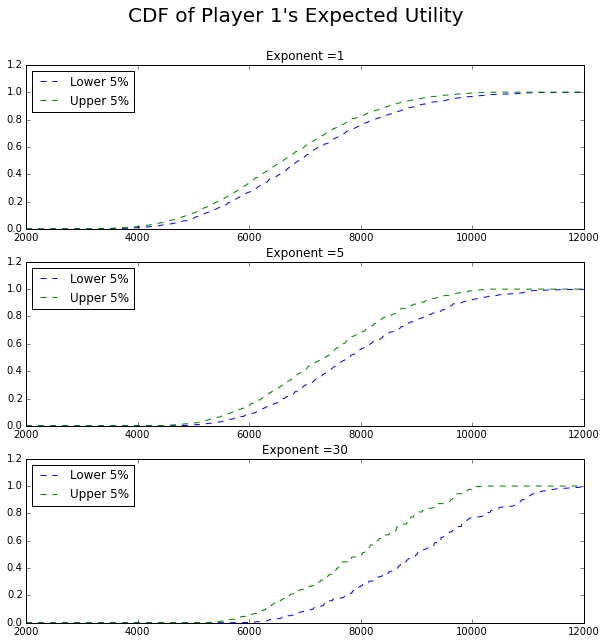

```python
plot_ci_cdf(convergence_results_5, pgtexact=False);
```

Just for the heck of it, let's see how the ranking compares to the traditional PGT exhaustive search distribution

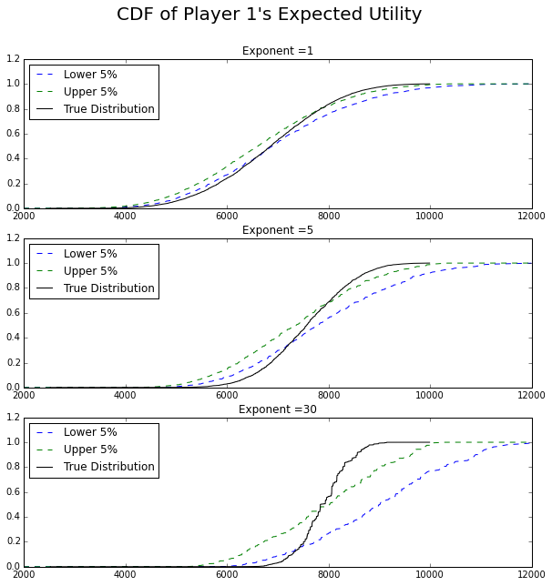

```python
plot_ci_cdf(convergence_results_5, pgtexact=True);
```

**Comment:** Even in the modified PGT algorithms, we will likely still need an "exponent" parameter to calibrate